# Lab 3A

## Linear Discriminant Analysis (LDA)

LDA is a classification method that models the distribution of the predictors within each class. It assumes that the predictors follow a multivariate normal distribution and that all classes share the same covariance matrix. Based on these assumptions, LDA finds a linear combination of the predictors that best separates the classes and uses it to classify new observations.

1. Perform a linear discriminant analysis on the `logspam` data. Save the fitted object under an appropriate name.

   **Hint:**Use `lda()` from the `MASS` package. The syntax is similar to standard formula modeling (e.g., `grouping` can also be handled via formula `type ~ .`).

**Show Answer**

```r
# LDA finds the axis (linear discriminant) that maximizes the separation between spam and nonspam.
train_lda <- lda(x = logspam[train, -58], grouping = logspam[train, 58])
```

2. Display and interpret the content of the `lda` object.

   **Hint:** The output displays prior probabilities (class baseline frequencies), group means, and the coefficients for the linear combinations (LD1).

**Show Answer**

```r
# The output provides the prior probabilities (proportions) of each class.
# Group means show average feature values per class, and LD1 coefficients dictate the final separation rule.
train_lda
```

```
## Call:
## lda(logspam[train, -58], grouping = logspam[train, 58])
##
## Prior probabilities of groups:
##   nonspam      spam
## 0.6059113 0.3940887
##
## Group means:
##               make     address        all       num3d        our       over
## nonspam -0.1427348 -0.07537983 -0.1860356 -0.06492357 -0.2750415 -0.2276730
## spam     0.2039634  0.10515643  0.2999063  0.08814443  0.4029711  0.3356713
##             remove   internet      order       mail    receive        will
## nonspam -0.3269620 -0.2221114 -0.2061075 -0.1755103 -0.2154628 -0.04562396
## spam     0.5200287  0.3351495  0.3105611  0.2615550  0.3442251  0.09966786
##             people      report  addresses       free   business      email
## nonspam -0.1313756 -0.07162572 -0.1715438 -0.3264510 -0.2464416 -0.2028312
## spam     0.1924712  0.12662715  0.2436677  0.5084748  0.3847111  0.3083448
##                you    credit       your        font     num000      money
## nonspam -0.2912079 -0.202943 -0.3832539 -0.09312505 -0.3121080 -0.2727319
## spam     0.4352654  0.318202  0.6057068  0.15837262  0.4762318  0.4189410
##                 hp        hpl     george     num650        lab       labs
## nonspam  0.2831802  0.2551045  0.2156779  0.1452101  0.1664418  0.1798659
## spam    -0.4333880 -0.3645872 -0.3369987 -0.2360231 -0.2250485 -0.2554901
##             telnet     num857       data     num415      num85 technology
## nonspam  0.1452240  0.1269499  0.1370601  0.1254415  0.1593469  0.1409463
## spam    -0.2043621 -0.1742175 -0.1878970 -0.1686748 -0.2464966 -0.1960688
##            num1999       parts         pm      direct          cs    meeting
## nonspam  0.1695023  0.03103701  0.1165508  0.05712563  0.08973556  0.1356734
## spam    -0.2693562 -0.02817914 -0.1925236 -0.07745629 -0.14775814 -0.2145809
##            original    project         re        edu       table  conference
## nonspam  0.09473595  0.1114400  0.1372592  0.1446909  0.03693645  0.08470925
## spam    -0.18566839 -0.1683413 -0.1988246 -0.2465663 -0.06200802 -0.13778224
##         charSemicolon charRoundbracket charSquarebracket charExclamation
## nonspam    0.04691323       0.09914813         0.0575312      -0.3850904
## spam      -0.09012265      -0.13205671        -0.0913432       0.5735821
##         charDollar   charHash capitalAve capitalLong capitalTotal
## nonspam -0.3487328 -0.1058139 -0.3659136  -0.4281711   -0.3574913
## spam     0.5265463  0.1518466  0.5446330   0.6272557    0.5312687
##
## Coefficients of linear discriminants:
```

[output cut: 43 more lines]

```
## original          -0.0065560292
## project           -0.0936495673
## re                -0.1018238695
## edu               -0.2082387325
## table             -0.0444796331
## conference        -0.0729156750
## charSemicolon     -0.1191664045
## charRoundbracket  -0.0307143327
## charSquarebracket -0.0170191629
## charExclamation    0.3607566702
## charDollar         0.2737593268
## charHash          -0.0097041407
## capitalAve         0.0041889060
## capitalLong        0.2303192724
## capitalTotal       0.1865292780
```

Do you agree with the follwing: The prior probabilities show that about 61% of the training emails are nonspam and 39% are spam. The group means indicate how the standardized feature values differ between spam and nonspam emails. Many words associated with spam (e.g., free, money, remove) have higher average values in spam emails, while words more typical of legitimate emails (e.g., hp, george) have higher averages in nonspam emails.

The linear discriminant coefficients (LD1) show how each feature contributes to separating spam from nonspam emails. Features with larger absolute coefficients have a stronger influence on the classification decision.

3. Plot the fitted object, and interpret its meaning.

   **Hint:** Passing an `lda` object directly into `plot()` will generate histograms or density plots of the discriminant scores.

**Show Answer**

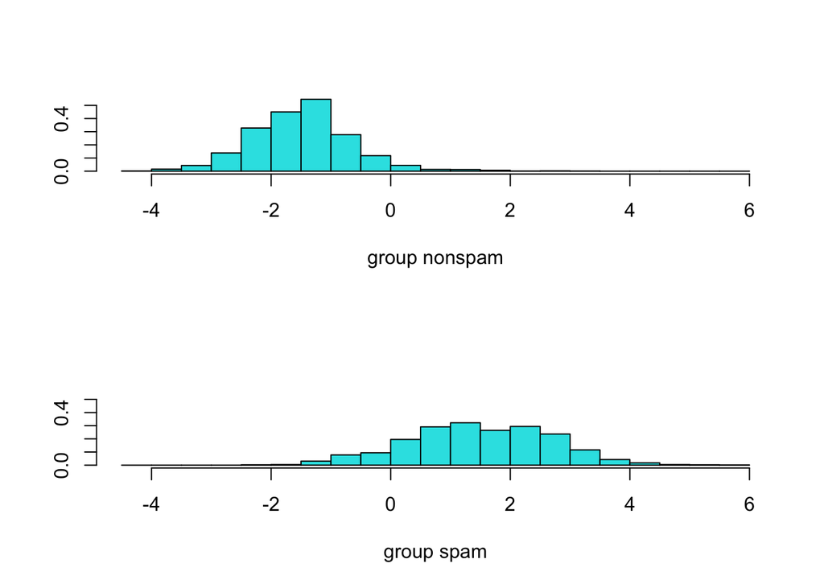

```r
# The histogram visualizes how well the LD1 axis separates the two classes.
# Less overlap indicates a more confident classification model.
plot(train_lda)
```

# Model testing

We now evaluate the performance of the three logistic regression models and the LDA model on the **test set**.

1. Use the function `predict()` to obtain predictions for the test data. Consult the help pages for `predict.glm` and `predict.lda` to determine the appropriate arguments. Save the predicted values in objects with informative names (e.g., `pred_glm`, `pred_lasso`, etc.).

   **Hint:** For logistic regression (GLM and GLMNET), use `type = "response"` to output probabilities. `predict.lda()` returns a list containing multiple elements.

**Show Answer**

```r
# We use the models trained on the 75% training set to predict outcomes on the 25% holdout test set.
# For LDA, predict() outputs a list containing predicted classes and posterior probabilities.
pred_glm    <- predict(train_glm,
                            newdata = logspam[-train, -58],
                             type = "response")

pred_lasso  <- predict(train_cv.lasso,
                            newx = as.matrix(logspam[-train, -58]),
                            type = "response")

pred_ridge  <- predict(train_cv.ridge,
                            newx = as.matrix(logspam[-train, -58]),
                            type = "response")


pred_lda    <- predict(train_lda, logspam[-train, -58])
```

2. Inspect the predicted objects and determine how the predicted class labels can be obtained. For some models, you will need to convert predicted probabilities into the factor levels `"nonspam"` and `"spam"`, while for others the predicted classes can be extracted directly. Save these factors under appropriate names (e.g. `class_glm`, `class_lasso`, etc.).

   **Hint:** Convert probabilities to classes by applying a logical condition (e.g., `> 0.5`) and wrapping it in `factor()` with proper labels. For LDA, extract the `$class` element.

**Show Answer**

```r
# A 0.5 threshold is applied to the logistic models to assign a hard class label.
# The FALSE/TRUE boolean outcomes naturally map to "nonspam" and "spam" via the labels argument.
class_glm   <- factor(pred_glm > .5,
                         labels = c("nonspam", "spam"))

class_lasso <- factor(pred_lasso > 0.5,
                             labels = c("nonspam", "spam"))

class_ridge <- factor(pred_ridge > 0.5,
                             labels = c("nonspam", "spam"))

class_lda   <- pred_lda$class
```

3. Display the confusion matrices of the four models, and save them under appropriate names. Recall that a confusion matrix is a table comparing the **observed** and **predicted** classes, showing the numbers of true positives, true negatives, false positives, and false negatives.

   **Hint:** Use the `table()` function, comparing the actual test labels with your newly generated class predictions.

**Show Answer**

```r
# Creating a helper function to quickly generate cross-tabulations.
# The diagonal represents correct predictions (True Negatives and True Positives).
# Off-diagonals represent misclassifications (False Positives and False Negatives).
conf <- function(est) table(obs = logspam$type[-train], est = est)
conf <- function(est) table(obs = logspam$type[-train], est = est)

(conf_glm   <- conf(class_glm))
```

```
##          est
## obs       nonspam spam
##   nonspam     661   36
##   spam         31  422
```

```r
(conf_lasso <- conf(class_lasso))
```

```
##          est
## obs       nonspam spam
##   nonspam     669   28
##   spam         35  418
```

```r
(conf_ridge <- conf(class_ridge))
```

```
##          est
## obs       nonspam spam
##   nonspam     671   26
##   spam         44  409
```

```r
(conf_lda   <- conf(class_lda))
```

```
##          est
## obs       nonspam spam
##   nonspam     673   24
##   spam         52  401
```

   **Hint:** You can calculate accuracy by taking the sum of the diagonal of the confusion matrix and dividing it by the total sum of the matrix.

**Show Answer**

```r
# Calculating the ratio of incorrect predictions over the total number of test cases.
# Lower error rates indicate better generalization to unseen data.
miscl <- function(x) 1 - sum(diag(x)) / sum(x)

data.frame(glm   = miscl(conf_glm),
           lasso = miscl(conf_lasso),
           ridge = miscl(conf_ridge),
           lda   = miscl(conf_lda)) %>%
  round(4)
```

```
##      glm  lasso  ridge    lda
## 1 0.0583 0.0548 0.0609 0.0661
```

  Interpret the differences between these curves. Recall that the ROC curve shows the trade-off between the true positive rate and the false positive rate across all classification thresholds, and that a curve closer to the top-left corner indicates better classification performance.

  **Hint:** Use the `roc()` function from the `pROC` package. You can plot multiple curves by passing `add = TRUE` to the subsequent `plot()` calls.

**Show Answer**

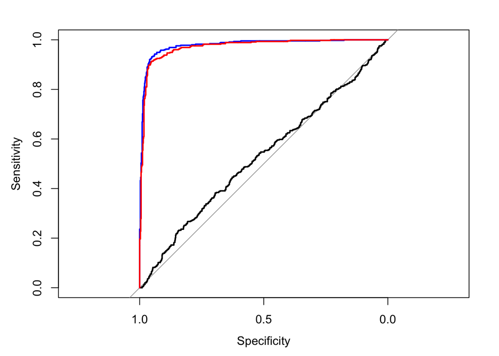

```r
# The ROC curve illustrates diagnostic ability across all possible probability thresholds.
# A larger Area Under the Curve (AUC) indicates a stronger ability to distinguish spam from nonspam.
# The random curve (black) runs diagonally, while GLM (blue) and LDA (red) bow towards the top left, showing strong predictive power.
plot(roc(logspam[-train, 58], runif(1150)))
plot(roc(logspam[-train, 58], pred_glm), add = T, col="blue")
plot(roc(logspam[-train, 58], pred_lda$posterior[, 2]), add = T, col="red")
```

# Bonus

1. Conduct all previous analyses on the original data (i.e. without the log transformations), and compare the misclassification error rates on the test set. Was the log transformation worth the effort?

   **Hint:** Simply swap `logspam` for `spam` in all functions, ensuring you rerun the models from scratch using the un-transformed dataset.

**Show Answer**

```r
# Fitting the entire suite of models on the original, un-transformed dataset.
# The resulting error rates can be directly compared to the log-transformed results to evaluate preprocessing impact.

# 1. Fit models
train_glm <- glm(type ~ . , family = "binomial", data = spam[train, ])

train_lasso <- glmnet(x = as.matrix(spam[train, -58]),
                      y = spam[train, 58],
                      family = "binomial")

train_ridge <- glmnet(x = as.matrix(spam[train, -58]),
                      y = spam[train, 58],
                      family = "binomial",
                      alpha = 0)

set.seed(1)
train_cv.lasso <- cv.glmnet(x = as.matrix(spam[train, -58]),
                            y = spam[train, 58],
                            family = "binomial",
                            nfolds = 5)
train_cv.ridge <- cv.glmnet(x = as.matrix(spam[train, -58]),
                            y = spam[train, 58],
                            family = "binomial",
                            nfolds = 5,
                            alpha = 0)

train_lda <- lda(x = spam[train, -58], grouping = spam[train, 58])

# 2. Predict
pred_glm    <- predict(train_glm,
                            newdata = spam[-train, -58],
                             type = "response")

pred_lasso  <- predict(train_cv.lasso,
                            newx = as.matrix(spam[-train, -58]),
                            type = "response")

pred_ridge  <- predict(train_cv.ridge,
                            newx = as.matrix(spam[-train, -58]),
                            type = "response")


pred_lda    <- predict(train_lda, spam[-train, -58])

# 3. Evaluate
class_glm   <- factor(pred_glm > .5,
                         labels = c("nonspam", "spam"))

class_lasso <- factor(pred_lasso > 0.5,
                             labels = c("nonspam", "spam"))

class_ridge <- factor(pred_ridge > 0.5,
                             labels = c("nonspam", "spam"))

class_lda   <- pred_lda$class

conf <- function(est) table(obs = spam$type[-train], est = est)

(conf_glm   <- conf(class_glm))
```

```
##          est
## obs       nonspam spam
##   nonspam     664   33
##   spam         42  411
```

```r
(conf_lasso <- conf(class_lasso))
```

```
##          est
## obs       nonspam spam
##   nonspam     659   38
##   spam         47  406
```

```r
(conf_ridge <- conf(class_ridge))
```

```
##          est
## obs       nonspam spam
##   nonspam     661   36
##   spam         62  391
```

```r
(conf_lda   <- conf(class_lda))
```

```
##          est
## obs       nonspam spam
##   nonspam     664   33
##   spam         88  365
```

```r
data.frame(glm   = miscl(conf_glm),
           lasso = miscl(conf_lasso),
           ridge = miscl(conf_ridge),
           lda   = miscl(conf_lda)) %>%
  round(4)
```

```
##      glm  lasso  ridge    lda
## 1 0.0652 0.0739 0.0852 0.1052
```

# Conclusion

In this lab we studied several classification methods for predicting whether an email is **spam** or **nonspam** using the `spam` dataset. The exploratory analysis showed that many predictors were strongly skewed and contained outliers, which motivated the use of a log transformation.

We then trained and compared standard logistic regression, regularized logistic regression (LASSO and ridge), and Linear Discriminant Analysis (LDA). The regularized models illustrated how shrinkage can reduce extreme coefficient estimates and improve model stability.

The models were evaluated on a separate test set using confusion matrices, misclassification error rates, and ROC curves. This showed how different classification methods can be compared not only by their predicted class labels, but also by the quality of their predicted probabilities.

Overall, the lab illustrated the full classification workflow: data exploration, preprocessing, model fitting, regularization, prediction, and performance evaluation on unseen data.

END OF LAB